# Question 1: Does Wage Discrimination Exist in Starting Salaries?

Author

Ha Tien Nguyen

Published

March 14, 2026

**Research Question:** Does wage discrimination exist in the starting salaries of faculty members (i.e., salaries in the year hired)?

**Significance level:** α = 0.05 (two-sided tests throughout).

# 1. Setup

```r
library(ggplot2)
library(dplyr)
library(sandwich)
library(lmtest)
```

# 2. Load & Clean Data

```r
df <- read.table("salary.txt", header = TRUE, strip.white = TRUE)
df$sex   <- factor(df$sex,   levels = c("M", "F"))
df$field <- factor(df$field)
```

## 2.1 Restrict to starting salary observations

Keep only rows where salary is observed in the year hired: one row per faculty member at hire.

```r
n_before <- nrow(df)
df <- df[df$startyr == df$year, ]
cat("After startyr == year filter:", nrow(df), "rows (removed", n_before - nrow(df), "non–hire-year rows)\n")
```

```
After startyr == year filter: 1107 rows (removed 18685 non–hire-year rows)
```

## 2.2 Verify rank at hire

Summary of `rank` at hire (as suggested in feedback): we check that rank is uniform or document its distribution before analysis.

```r
df$rank <- factor(df$rank)
table(df$rank)
```

```
Assist  Assoc   Full
   802    176    129
```

The table above shows the distribution of rank at hire; we use it to verify that rank is (or is not) uniform at hire before analysis and to document any deviations from uniform rank at hire.

## 2.3 Distribution of starting salary and transformation

We check the distribution of starting salary in Section 3 (boxplots and histograms). If the distribution is right-skewed, we use $\log(\text{salary})$ in regression (Section 4.3) to improve normality and interpret the sex coefficient as an approximate percentage difference. The descriptive plots in Section 3 support using a log transformation.

## 2.4 Final Dataset

```r
cat("Final dataset:", nrow(df), "faculty members\n")
```

```
Final dataset: 1107 faculty members
```

```r
cat("  Female:", sum(df$sex == "F"), " | Male:", sum(df$sex == "M"), "\n")
```

```
  Female: 354  | Male: 753
```

```r
cat("  Hire years:", min(df$startyr), "–", max(df$startyr), "\n")
```

```
  Hire years: 76 – 95
```

```r
cat("  Salary range: $", min(df$salary), "– $", max(df$salary), "\n")
```

```
  Salary range: $ 1267 – $ 14464
```

# 3. Descriptive Statistics

## 3.1 Summary by Sex

```r
tapply(df$salary, df$sex, function(x) {
  round(c(n = length(x), mean = mean(x), median = median(x),
          sd = sd(x), IQR = IQR(x)), 2)
})
```

```
$M
      n    mean  median      sd     IQR
 753.00 4015.55 3719.00 1933.31 2076.00

$F
      n    mean  median      sd     IQR
 354.00 3600.32 3502.50 1347.82 1477.00
```

## 3.2 Boxplots by Sex

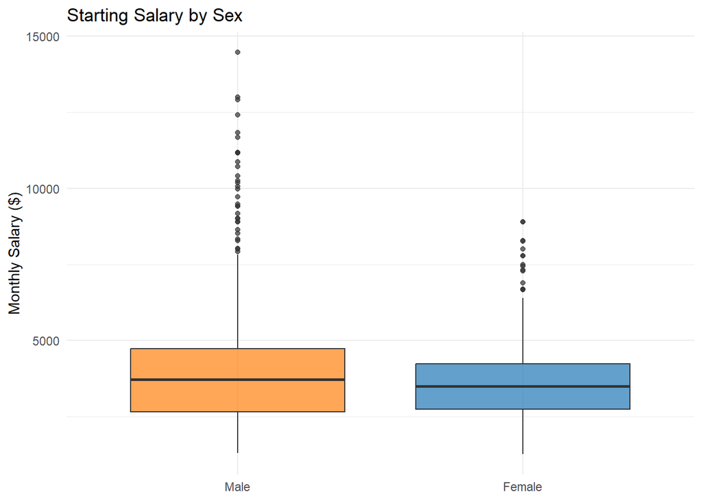

```r
ggplot(df, aes(x = sex, y = salary, fill = sex)) +
  geom_boxplot(alpha = 0.7) +
  scale_x_discrete(labels = c(M = "Male", F = "Female")) +
  scale_fill_manual(values = c(M = "#ff7f0e", F = "#1f77b4"), guide = "none") +
  labs(title = "Starting Salary by Sex", x = NULL, y = "Monthly Salary ($)") +
  theme_minimal()
```

## 3.3 Histograms by Sex

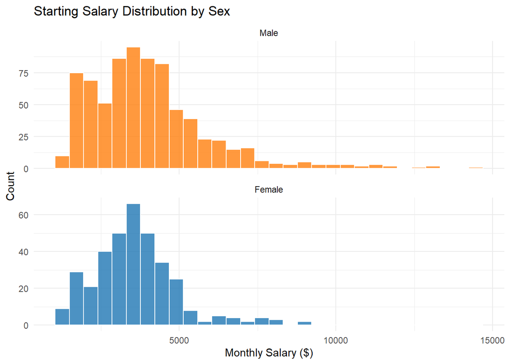

```r
ggplot(df, aes(x = salary, fill = sex)) +
  geom_histogram(bins = 30, colour = "white", alpha = 0.8) +
  facet_wrap(~sex, ncol = 1, scales = "free_y",
             labeller = labeller(sex = c(M = "Male", F = "Female"))) +
  scale_fill_manual(values = c(M = "#ff7f0e", F = "#1f77b4"), guide = "none") +
  labs(title = "Starting Salary Distribution by Sex", x = "Monthly Salary ($)", y = "Count") +
  theme_minimal()
```

## 3.4 Summary by Field and Sex

```r
aggregate(salary ~ field + sex, data = df,
          FUN = function(x) round(c(n = length(x), mean = mean(x), sd = sd(x)), 2))
```

```
  field sex salary.n salary.mean salary.sd
1  Arts   M    76.00     3136.84   1371.91
2 Other   M   480.00     4047.94   1916.73
3  Prof   M   197.00     4275.61   2066.86
4  Arts   F    71.00     3082.57    891.94
5 Other   F   247.00     3610.25   1333.65
6  Prof   F    36.00     4553.33   1658.59
```

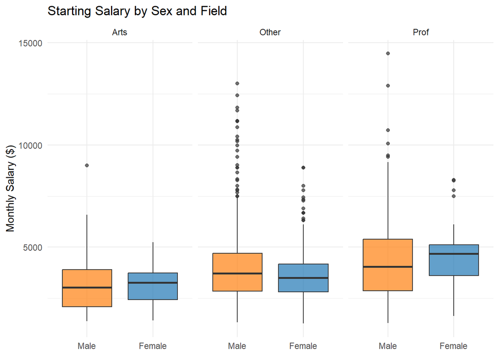

```r
ggplot(df, aes(x = sex, y = salary, fill = sex)) +
  geom_boxplot(alpha = 0.7) +
  facet_wrap(~field) +
  scale_x_discrete(labels = c(M = "Male", F = "Female")) +
  scale_fill_manual(values = c(M = "#ff7f0e", F = "#1f77b4"), guide = "none") +
  labs(title = "Starting Salary by Sex and Field", x = NULL, y = "Monthly Salary ($)") +
  theme_minimal()
```

## 3.5 Salary by Hire Cohort

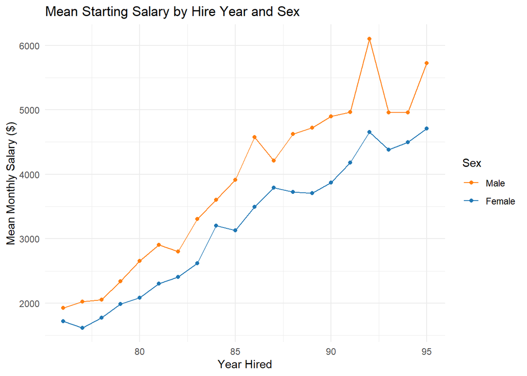

```r
cohort <- df %>%
  group_by(startyr, sex) %>%
  summarise(mean_sal = mean(salary), .groups = "drop")

ggplot(cohort, aes(x = startyr, y = mean_sal, colour = sex)) +
  geom_line() +
  geom_point() +
  scale_colour_manual(values = c(M = "#ff7f0e", F = "#1f77b4"),
                      labels = c(M = "Male", F = "Female")) +
  labs(title = "Mean Starting Salary by Hire Year and Sex",
       x = "Year Hired", y = "Mean Monthly Salary ($)", colour = "Sex") +
  theme_minimal()
```

## Boxplots and histograms show the female distribution shifted lower than the male distribution (see figures on pages 3–4).

# 4. Inferential Analysis

## 4.1 Welch Two-Sample t-Test

$H_0: \mu_F = \mu_M$ vs $H_A: \mu_F \neq \mu_M$

```r
t.test(salary ~ sex, data = df, alternative = "two.sided")
```

```
    Welch Two Sample t-test

data:  salary by sex
t = 4.1326, df = 949.26, p-value = 3.904e-05
alternative hypothesis: true difference in means between group M and group F is not equal to 0
95 percent confidence interval:
 218.0416 612.4033
sample estimates:
mean in group M mean in group F
       4015.545        3600.323
```

Because the p-value is < 0.05, we reject the null hypothesis of equal means. Although the starting-salary distribution is right-skewed, the sample size is large, so by the central limit theorem the sampling distribution of the mean difference is approximately normal and the Welch t-test remains appropriate.

## 4.2 Multiple Linear Regression (Salary Level)

$$Y_i = \beta_0 + \beta_1\text{Female}_i + \beta_2\text{Field}_i + \beta_3\text{YrDeg}_i + \beta_4\text{HireYear}_i + \varepsilon_i$$

```r
ols <- lm(salary ~ sex + field + yrdeg + startyr, data = df)
coeftest(ols, vcov = vcovHC(ols, type = "HC3"))
```

```
t test of coefficients:

               Estimate  Std. Error  t value  Pr(>|t|)
(Intercept) -12782.6525    477.9967 -26.7421 < 2.2e-16 ***
sexF          -291.2120     67.4831  -4.3153 1.737e-05 ***
fieldOther     483.2976     64.7661   7.4622 1.723e-13 ***
fieldProf     1122.4886     92.6653  12.1134 < 2.2e-16 ***
yrdeg         -113.5642      9.1477 -12.4146 < 2.2e-16 ***
startyr        292.1267     11.5307  25.3347 < 2.2e-16 ***
---
Signif. codes:  0 '***' 0.001 '**' 0.01 '*' 0.05 '.' 0.1 ' ' 1
```

```r
summary(ols)$r.squared
```

```
[1] 0.6103126
```